# MMID Practical: Model Extensions

Ricardo Águas

MSc MGH course, 2022

Implement a SACRD type model structure as depicted below in R.

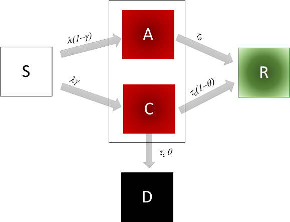

Use the following set of parameters in a population of size 1000, as starting point:

```r
parameters <- c(
  mu = (1/(50*52*7)),
  beta = 0.25,
  gamma = 0.2,
  taua = 1/10,
  tauc = 1/10,
  phi=0.05
)
```

If you successfully implement a SACRD function and run the code below, you should see the similar output as the one here.

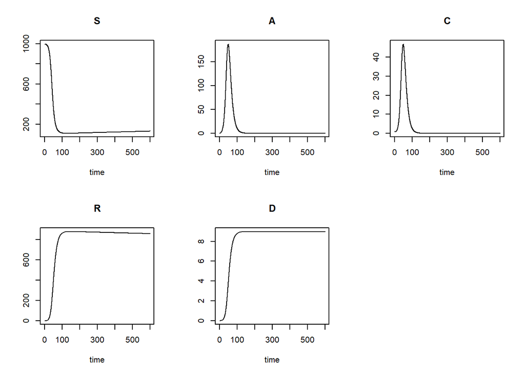

```r
out <- deSolve::ode(y = istate, times = tps, func = SACRD, parms = parameters)
plot(out)
```

Compare the infection prevalence against that generated by an SIR model that uses the same parameters and initial conditions.

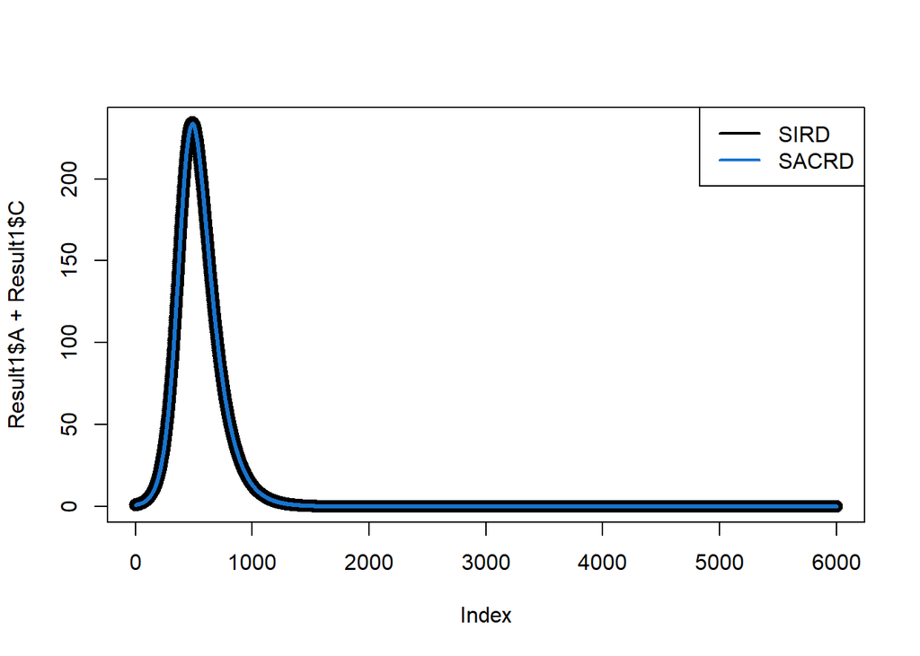

```r
par(mfrow = c(1, 1))
plot(Result1$A + Result1$C, col = "black", lwd = 3)
lines(Result2$I, col = "dodgerblue3", lwd = 3)
legend("topright", legend = c("SIRD", "SACRD"), lwd = 2,
    col = c("black", "dodgerblue3"))
```

Now consider that asymptomatic infections might, on average, last longer than clinical infections, since the later tend to be treated and asymptomatic infections go undiagnosed. Increase the duration of asymptomatic infections in the SACRD model and compare the outputs against the previous results. If you double the infectious period for asymptomatics you should see something like this:

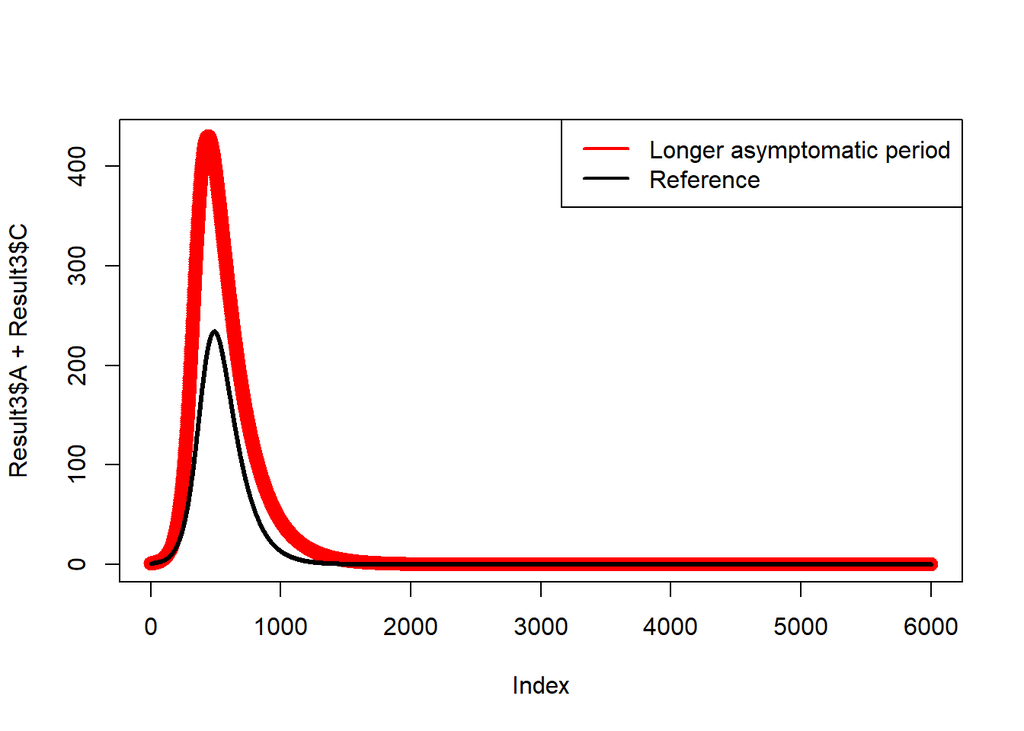

Now repeat a similar analysis but starting with a lower beta value. Reset all SACRD model parameters to their original values as given in this document and change beta to 0.09. What is the corresponding R0 value given the parameters and the model structure?

Show the prevalence of infection over time for that model. Juxtapose it with the predicted prevalence with the same model but changing asymptomatic infection duration to be twice as long as clinical infections.

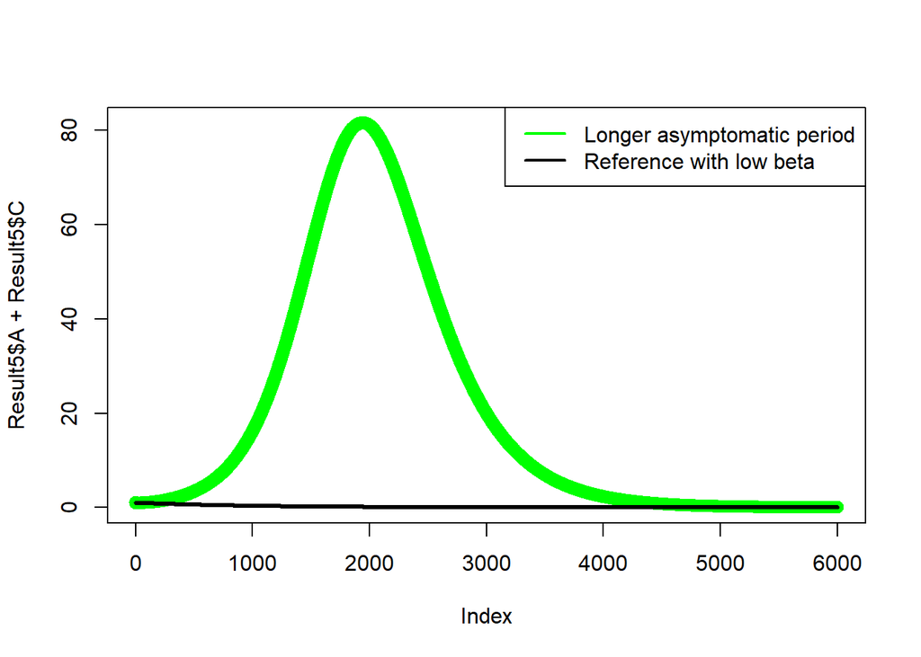

Now impose that those who are asymptomatic are 25% less infective than clinical cases. Add the projected prevalence with those parameters to the previous graph.

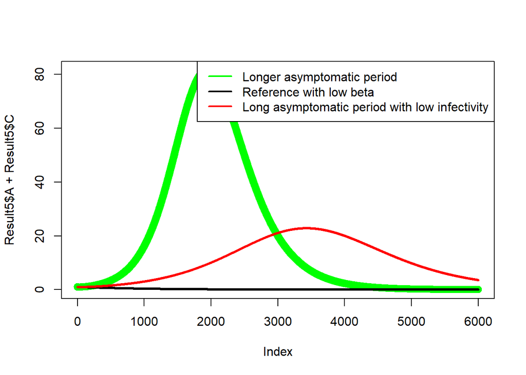

In reality, most people do not become infectious right after they become infected. The period between the moment of infection and becoming infectious is typically referred to as the incubation period. Most models make the simplifying assumption that infectiousness starts on symptom presentation; thus the typical representation of the I class as reflecting both infectivity and symptomatology. In some cases, people can become infectious before they present with any symptoms. How would you incorporate such detail into the previous model? Draw the diagram below.

When adding an incubation or exposed compartment to a model, we need to decide what assumptions to make regarding: - Length of incubation period - Infectivity of incubation period

Explore ranges of both those parameters and write down your understanding of the relative importance of both to the observed dynamics. To add a bit more perspective, output the predicted final attack size (cumulative number of infections) for all explored parameter values.

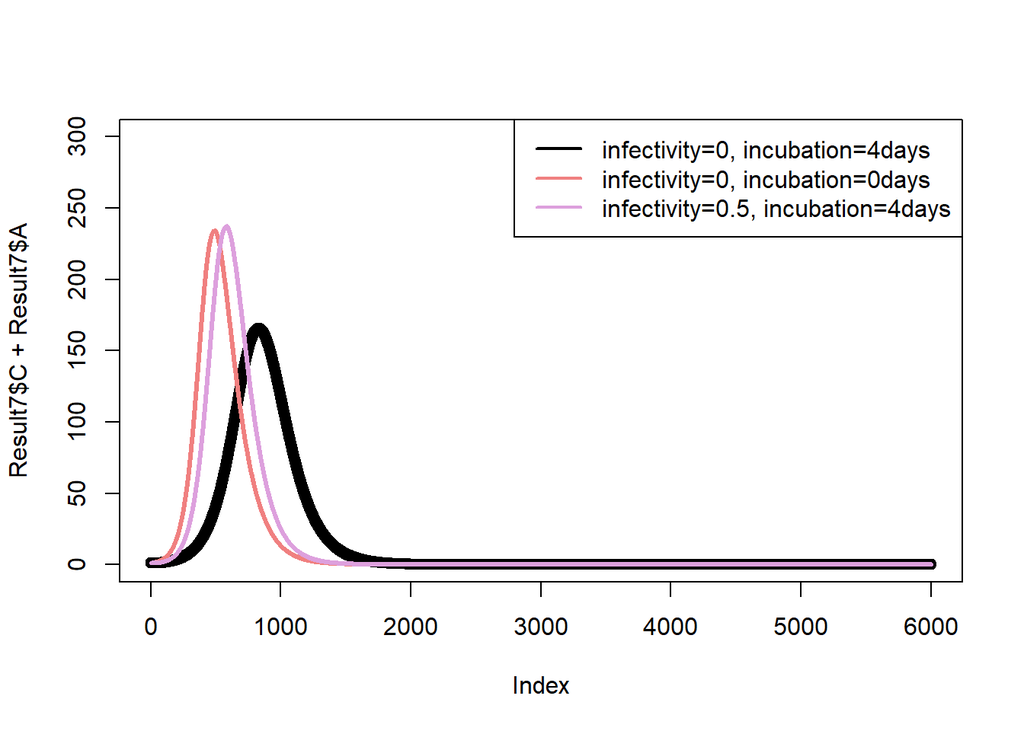

```r
v_vector<-seq(0.1,1,by=0.1)
delta_vector<-(seq(0.2,1,by=0.1))
result<-matrix(0,nrow = length(v_vector),length(delta_vector))
```

You should be able to generate a contour plot like the figure below

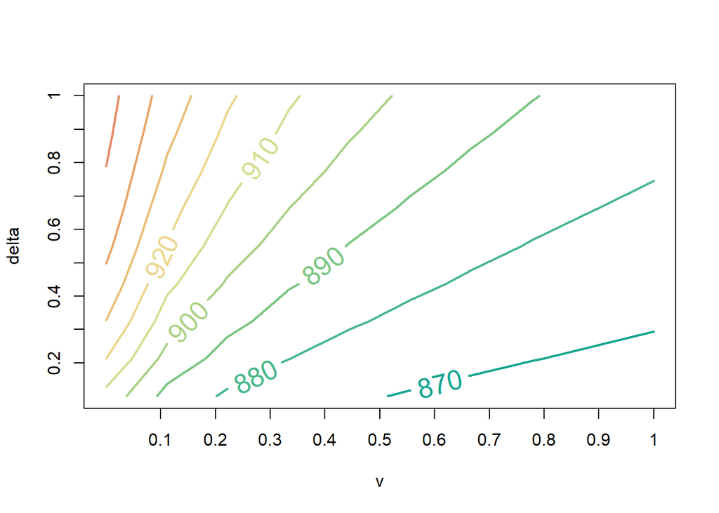

```r
contour(result,xaxt = "n", yaxt = "n",xlab="v",ylab="delta",nlevels = 10, labcex=1.6,col = hcl.colors(12, "Temps"),lwd =2)
axis(1, at=1:length(v_vector)/length(v_vector), labels=v_vector)
axis(2, at=1:length(delta_vector)/length(delta_vector), labels=delta_vector)
```

Write down your understanding of these results.

Finally, consider a model with partial and temporary immunity. A generic framework that can be adopted to almost any infectious disease is illustrated below.

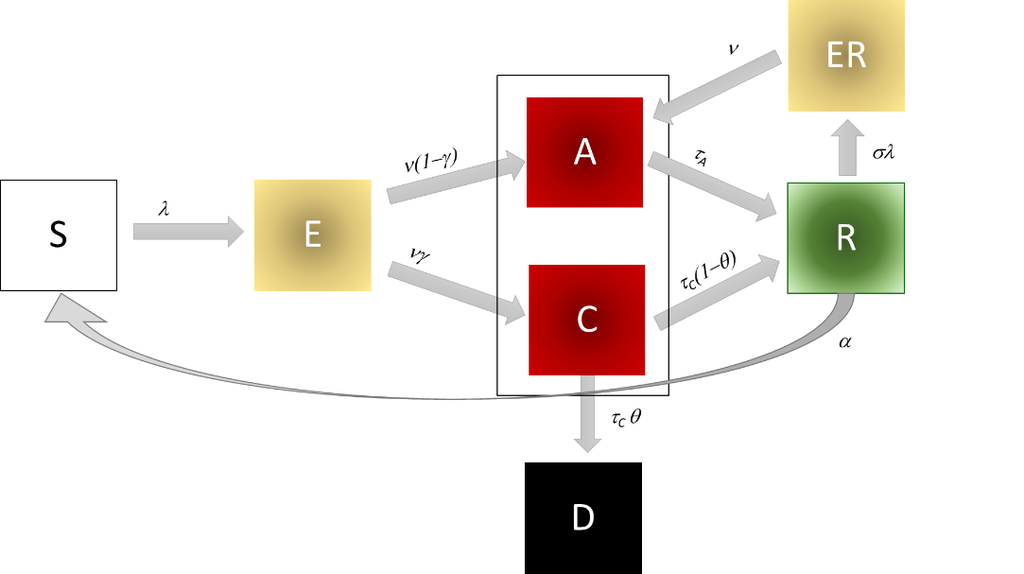

For the parameter set below explore the trade-off between infection and immunity loss.

```r
parameters <- c(
  mu = (1/(50*52*7)),
  beta = 0.25,
  v = 1/4,
  gamma = 0.2,
  taua = 1/10,
  tauc = 1/10,
  phi = 0.05,
  rho = 1,
  sigma = 0.5,
  alpha = 1/180,
  delta_r = 0.0,
  delta=0.0
)
```

Do so by performing a sensitivity analysis, similar to the one above, over the following parameter space

```r
beta_vector<-seq(0.1,3,by=0.2)
alpha_vector<-(seq(0.003,0.01,by=0.001))
result<-matrix(0,nrow = length(beta_vector),length(alpha_vector))
```

You should get a contour plot that looks like this

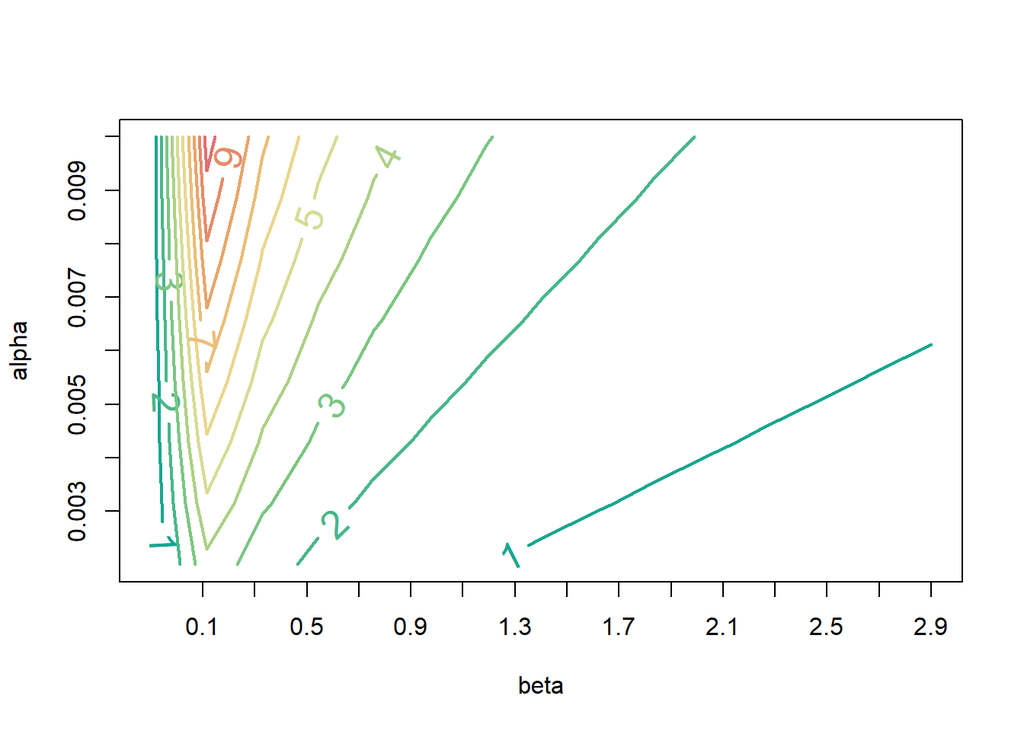

Interpret the results – you might remember a similar result presented in the paper we discussed 2 weeks ago (https://pubmed.ncbi.nlm.nih.gov/16439331/). Note that in this case, the peak at intermediate beta values is not observed in clinical cases only, but in the overall number of cases. What do you think is responsible for such dynamics?